# Estatística Experimental - IC 284

Exercício - Aula 2

Antônio Gonçalves Wagner Tassinari

2022

[figure not shown]

# Pacote Estatístico R via Google Colab

- Podemos resolver os exercícios utilizando o **pacote estatístico R** através do [Google Colab](https://colab.research.google.com/#create=true&language=r). Google Colab (ou Colaboratory) é um notebook interativo fornecido pelo Google para escrever e executar Python por meio de um navegador. Embora o Colab seja usado principalmente para codificação em Python, atualmente também podemos usá-lo para compilar o R.
- Podemos realizar análise de dados, criar modelos, avaliar esses modelos via Colab. O processamento é feito em servidores de propriedade do Google na nuvem. Precisamos apenas de um navegador e uma conexão de internet bastante estável. O Colab é uma ótima ferramenta alternativa para facilitar nosso trabalho, seja como estudante, profissional ou pesquisador. ([link](https://colab.to/r))

# Exercício 1

- Determinar o peso médio e a variância de uma cana de certa variedade no canavial de uma usina de uma amostra aleatória, em diversos pontos da lavoura. Pesos em quilogramas, como mostrado a seguir:

| Pesos (Kg) |  |
| --- | --- |
| 1,58 | 1,32 |
| 1,76 | 1,51 |
| 1,38 | 1,55 |
| 1,71 | 1,54 |
| 1,50 | 1,67 |

```r
# Entrando com os dados
pesos <- c(1.58, 1.32, 1.76, 1.51, 1.38, 1.55, 1.71, 1.54, 1.5, 1.67)

# Média
mean(pesos)
```

```
[1] 1.552
```

```r
# Variância
var(pesos)
```

```
[1] 0.01899556
```

```r
# Sumário estatístico
summary(pesos)
```

```
   Min. 1st Qu.  Median    Mean 3rd Qu.    Max.
  1.320   1.502   1.545   1.552   1.647   1.760
```

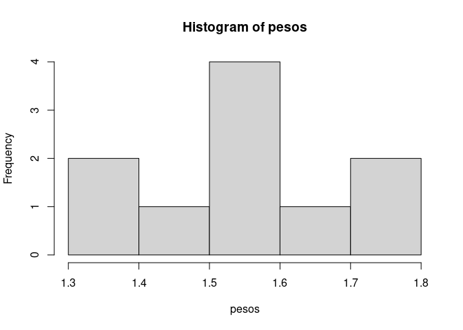

```r
# Histograma
hist(pesos)
```

```r
# Utilizando o pacote pastecs
library(pastecs)
stat.desc(pesos, norm = T)
```

```
     nbr.val     nbr.null       nbr.na          min          max        range
 10.00000000   0.00000000   0.00000000   1.32000000   1.76000000   0.44000000
         sum       median         mean      SE.mean CI.mean.0.95          var
 15.52000000   1.54500000   1.55200000   0.04358389   0.09859361   0.01899556
     std.dev     coef.var     skewness     skew.2SE     kurtosis     kurt.2SE
  0.13782436   0.08880436  -0.12161111  -0.08850328  -1.20632230  -0.45206049
  normtest.W   normtest.p
  0.96622290   0.85378834
```

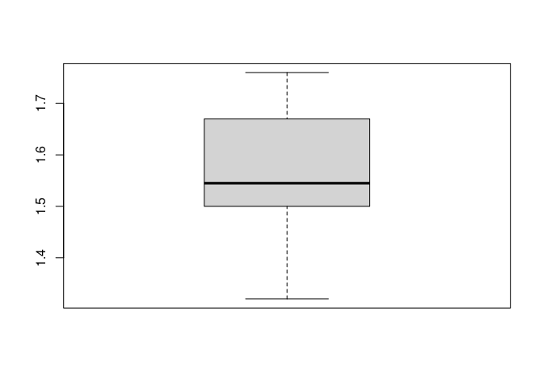

```r
# Boxplot
boxplot(pesos)
```

# Exercício 3

Suponhamos um experimento para decidir sobre a eficácia de 2 tipos de adubo A e B em relação ao crescimento de um cultivar. Cada um aplicado a 18 e 21 cultivares, respectivamente.

| Adubo A |  |  | Adubo B |  |  |
| --- | --- | --- | --- | --- | --- |
| 45 | 60 | 54 | 57 | 55 | 58 |
| 62 | 55 | 70 | 50 | 52 | 59 |
| 38 | 48 | 64 | 59 | 55 | 56 |
| 55 | 56 | 55 | 61 | 52 | 53 |
| 54 | 59 | 48 | 57 | 57 | 50 |
| 65 | 55 | 60 | 55 | 58 | 54 |
|  |  |  | 59 | 51 | 56 |

1. Para verificar a homogeneidade das duas populações, um pesquisador sugeriu que se usasse o quociente $F = \dfrac{var(X/A )}{var(X/B)}$, mas não disse qual decisão tomar baseado nesse valor. Que regra de decisão você adotaria ?
2. Faça um box plot para os dados referentes aos adubos A e B. Compare os dois conjuntos de dados por meio desses desenhos.
3. Para decidir se os resultados dos dois adubos são semelhantes ou não, adotou-se o seguinte teste:

$$t = \dfrac{\bar{x}_A -\bar{x}_B}{S_p \sqrt{\dfrac{1}{n_{A}} + \dfrac{1}{n_{B}}}}$$
Sabendo que,

$$S_p = \dfrac{(n_{A} - 1)var(x_A) + (n_{B} - 1)var(x_B)}{n_{A} + n_{B} - 2}$$
sejam $n_A$ e $n_B$ o tamanho das amostras.

4. Caso $|t| < 2$ os resultados são semelhantes, caso contrário, são diferentes. Qual seria a sua conclusão ?

```r
# Entrando com os dados

crescimento <- c(45, 60, 54, 62, 55, 70, 38, 48, 64, 55, 56, 55, 54, 59, 48, 65,
    55, 60, 57, 55, 58, 50, 52, 59, 59, 55, 56, 61, 52, 53, 57, 57, 50, 55, 58, 54,
    59, 51, 56)

adubos <- c("A", "A", "A", "A", "A", "A", "A", "A", "A", "A", "A", "A", "A", "A",
    "A", "A", "A", "A", "B", "B", "B", "B", "B", "B", "B", "B", "B", "B", "B", "B",
    "B", "B", "B", "B", "B", "B", "B", "B", "B")

dados <- data.frame(crescimento, adubos)

View(dados)
```

```r
# Análise exploratória utilizando o pacote pastecs
library(pastecs)

stat.desc(dados$crescimento[dados$adubos == "A"], norm = T)
```

```
      nbr.val      nbr.null        nbr.na           min           max
  18.00000000    0.00000000    0.00000000   38.00000000   70.00000000
        range           sum        median          mean       SE.mean
  32.00000000 1003.00000000   55.00000000   55.72222222    1.80920948
 CI.mean.0.95           var       std.dev      coef.var      skewness
   3.81709833   58.91830065    7.67582573    0.13775161   -0.37048841
     skew.2SE      kurtosis      kurt.2SE    normtest.W    normtest.p
  -0.34542577   -0.19943526   -0.09608605    0.96657703    0.73142536
```

```r
stat.desc(dados$crescimento[dados$adubos == "B"], norm = T)
```

```
      nbr.val      nbr.null        nbr.na           min           max
  21.00000000    0.00000000    0.00000000   50.00000000   61.00000000
        range           sum        median          mean       SE.mean
  11.00000000 1164.00000000   56.00000000   55.42857143    0.69203437
 CI.mean.0.95           var       std.dev      coef.var      skewness
   1.44355839   10.05714286    3.17129987    0.05721417   -0.22285770
     skew.2SE      kurtosis      kurt.2SE    normtest.W    normtest.p
  -0.22232646   -1.11940756   -0.57586187    0.95664750    0.45133675
```

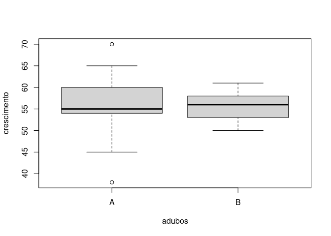

```r
# Boxplot

boxplot(crescimento ~ adubos, dados)
```

### Teste para razão de duas variâncias populacionais, $\sigma_1$ e $\sigma_2$

$\left\{ \begin{array}{ll} H_0: \sigma_{1}^{2} = \sigma_{2}^{2} \rightarrow \dfrac{\sigma_{1}^{2}}{\sigma_{2}^{2}} = 1 \\ H_1: \sigma_{1}^{2} \neq \sigma_{2}^{2} \rightarrow \dfrac{\sigma_{1}^{2}}{\sigma_{2}^{2}} \neq 1 \end{array} \right.$

- Sabemos que $F_{calc} = \dfrac{58.92}{10.06} = 5,86$

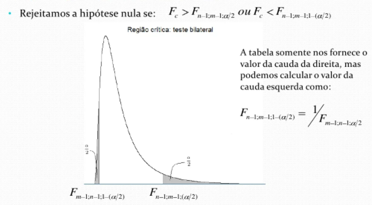

Supondo $\alpha = 5\%$, os valores críticos (na tabela F) são:

$F_{tab_1} = 1/F_{(n_{2}-1; n_{1}-1; \alpha/2)} = 1/F_{(20; 17; 0,025)} = 1/2,616 = 0,382$

$F_{tab_2} = F_{(n_{1}-1; n_{2}-1; \alpha/2)} = F_{(17; 20; 0,025)} \sim 1/F_{(20; 20;0, 025)} = 2,464$

- **OBS:** Ver a tabela da distribuição F ([link](https://drive.google.com/file/d/18ohSefWPh0qumBWPGUya0Td5pZSky1Jw/view?usp=sharing))

```r
# Calculando no R valor crítico ou tabelado 1
qf(0.025, 17, 20, lower.tail = TRUE)
```

```
[1] 0.3822924
```

```r
# valor critico ou tabelado 2
qf(0.025, 17, 20, lower.tail = FALSE)
```

```
[1] 2.52279
```

**Decisão:** Como $F_{calc} > F_{tab_2}$ e $5,86 > 2.52$, rejeito $H_0$. Com $5\%$ de significância, podemos dizer que existem evidências de que exista diferença entre as populações quanto a dispersão.

```r
# Teste F para razão entre as variâncias

var.test(crescimento ~ adubos, dados)
```

```
    F test to compare two variances

data:  crescimento by adubos
F = 5.8584, num df = 17, denom df = 20, p-value = 0.0002943
alternative hypothesis: true ratio of variances is not equal to 1
95 percent confidence interval:
  2.322173 15.324277
sample estimates:
ratio of variances
          5.858354
```

**Decisão:** Como $p-valor < \alpha = 0,05$, rejeita-se $H_0$ ao nível de $5\%$ de significância. Podemos dizer então que existem evidências de que exista diferença entre as populações quanto a dispersão.

### Teste para comparação entre duas médias populacionais, $\mu_1$ e $\mu_2$

$\left\{ \begin{array}{ll} H_0: \mu_1 = \mu_2 \\ H_1: \mu_1 \neq \mu_2 \end{array} \right.$

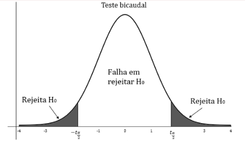

Supondo $\alpha = 5\%$, os valores críticos (na tabela t) são:

$t_{tab} = t_{(n_{1} + n_{2} - 2; \alpha)} = t_{(18 + 21 -2; 0,05)} = t_{(37; 0,05)} = 2,04$

- **OBS:** Ver a tabela da distribuição t | [link](https://drive.google.com/file/d/1af6fb6C-wZVIBAZhUZ347_igvjvSIExs/view?usp=sharing)

```r
# Valores críticos no R:
qt(0.025, 37, lower.tail = T)
```

```
[1] -2.026192
```

```r
qt(0.975, 37, lower.tail = T)
```

```
[1] 2.026192
```

**Decisão:** Como $- t_{tab} \leq t_{calc} \leq t_{tab}$, ou seja, $- 2,04 \leq 0,158 \leq 2,04$, não rejeita-se $H_{0}$. Podemos dizer que com 5% de significância, não existe evidências estatísticas de haver diferença entre as médias dos crescimentos entre ambos os grupos.

```r
# Teste T (teste para diferença entre médias) para dados independentes

t.test(crescimento ~ adubos, dados, var.equal = FALSE)
```

```
    Welch Two Sample t-test

data:  crescimento by adubos
t = 0.1516, df = 21.939, p-value = 0.8809
alternative hypothesis: true difference in means between group A and group B is not equal to 0
95 percent confidence interval:
 -3.724183  4.311485
sample estimates:
mean in group A mean in group B
       55.72222        55.42857
```

**Decisão:** Como $p-valor > \alpha = 0,05$, não rejeita-se $H_0$ ao nível de $5\%$ de significância. Podemos dizer que não existe evidências estatísticas de haver diferença entre as médias dos crescimentos entre ambos os grupos.